# Analysis of financial asset

Arthur Skobnikov

Friday, March 30, 2015

“The final project for the”Systems and Signals" course. It has purly learning goals and can not be used in a real analysis of a financial asset"

> Given a dataset of prices of financial asset (time series)

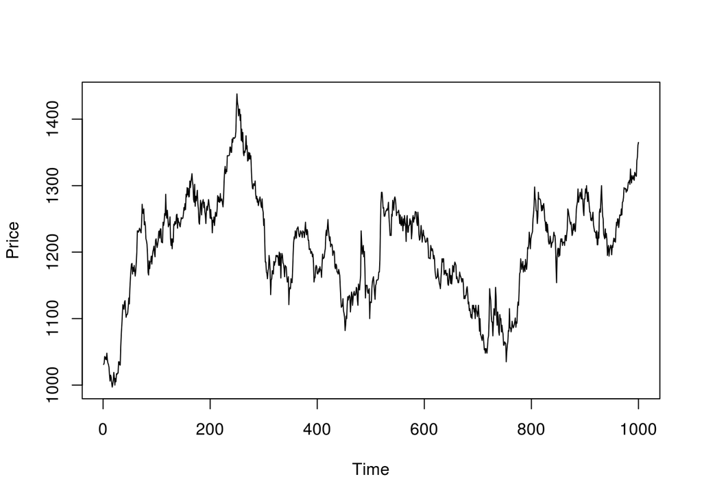

```r
X <- read.table("data.txt", header = TRUE, dec = ",")
X <- as.vector(X[, 1])
N <- length(X)
n <- 1:N
plot.ts(X, type='l', xlab = 'Time', ylab = 'Price' )
```

## PART 1 : create a model

> We suppose that process is linear and has a look: $X = m + Y$

### Hypothesis 1 : model *m* is polynomial of order 1: $m = a + b*n$

```r
m1 <- lm(X ~ n)     # lm() is a built-in function for generating a model
summary <- summary(m1)
a <- summary$coefficients[1, 1]
b <- summary$coefficients[2, 1]
cat("model: ", "m =", a, "+", b, "* n")
```

```
## model:  m = 1204.286 + 0.006050757 * n
```

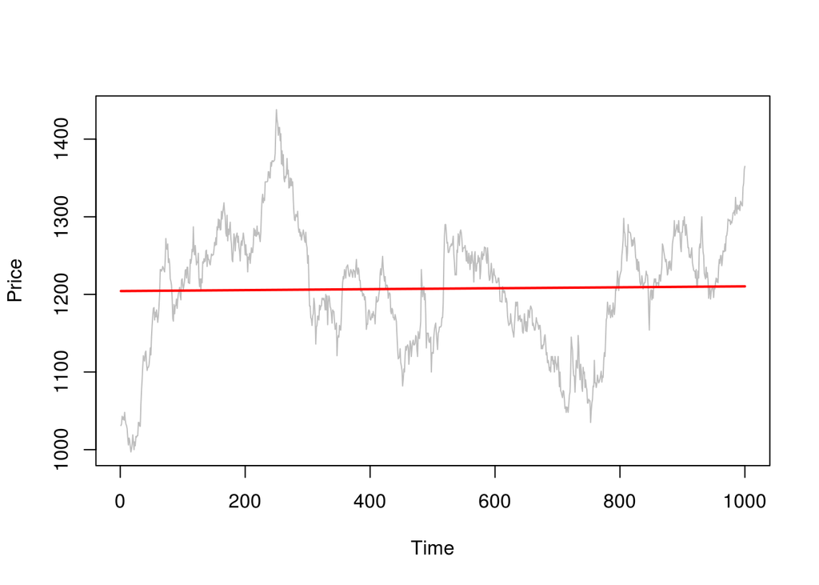

```r
plot.ts(X, type='l', col='gray', xlab = 'Time', ylab = 'Price' )
lines(n, predict(m1), lwd = 2, col = 'red')
```

> **Problem** : curve of linear model does not fit the data. Let’s check the coeficient of determination R² = Explained variation / Total variation

```r
r.squared <- summary$r.squared
cat("R²", r.squared)
```

```
## R² 0.00050874
```

> R² is almost zero. Variance of time `n` does not explain variance of price `X`. **Conclusion** : Model does not fit the given data.

### Hypothesis 2 : model is polynomial of second order $m = a + b_1*n + b_2*n^2$

> Repeating the same actions we did before gives us the following results :

```r
m2 <- lm(X ~ poly(n, 2, raw=TRUE))
summary <- summary(m2)
a <- summary$coefficients[1, 1]
b1 <- summary$coefficients[2, 1]
b2 <- summary$coefficients[3, 1]
cat("model: ", "m =", a, "+", b1, "* n", "+", b2, "* n?")
```

```
## model:  m = 1216.315 + -0.06597986 * n + 7.195866e-05 * n?
```

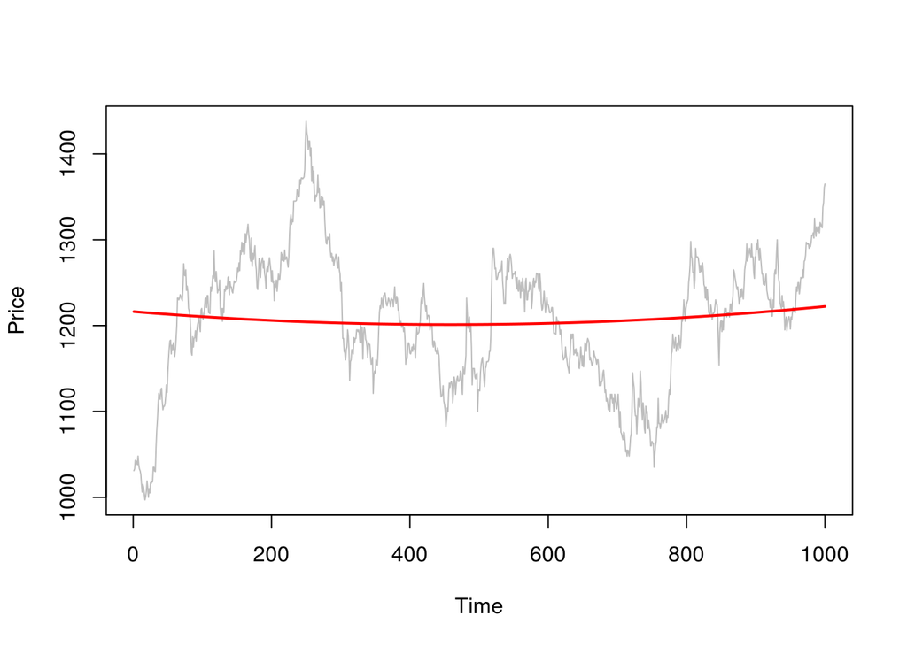

```r
plot.ts(X, type='l', col='gray', xlab = 'Time', ylab = 'Price' )
lines(n, predict(m2), lwd = 2, col = 'red')
```

```r
r.squared <- summary$r.squared
cat("R² =", r.squared)
```

```
## R² = 0.005305518
```

> This time we obtained the same problem as before. Model does not fit the data. Let’s try again with another model.

### Hypothesis 3 : model is polynomial of third order $m = a + b_1*n + b_2*n^2 + b_3*n^3$

> Repeating the same actions we did before gives us the following results :

```r
m3 <- lm(X ~ poly(n, 3, raw=TRUE))
summary <- summary(m3)
a <- summary$coefficients[1, 1]
b1 <- summary$coefficients[2, 1]
b2 <- summary$coefficients[3, 1]
b3 <- summary$coefficients[4, 1]
cat("model: ", "m =", a, "+", b1, "* n", "+", b2, "* n^2", "+", b3, "* n^3")
```

```
## model:  m = 1082.608 + 1.532908 * n + -0.003919272 * n^2 + 2.658162e-06 * n^3
```

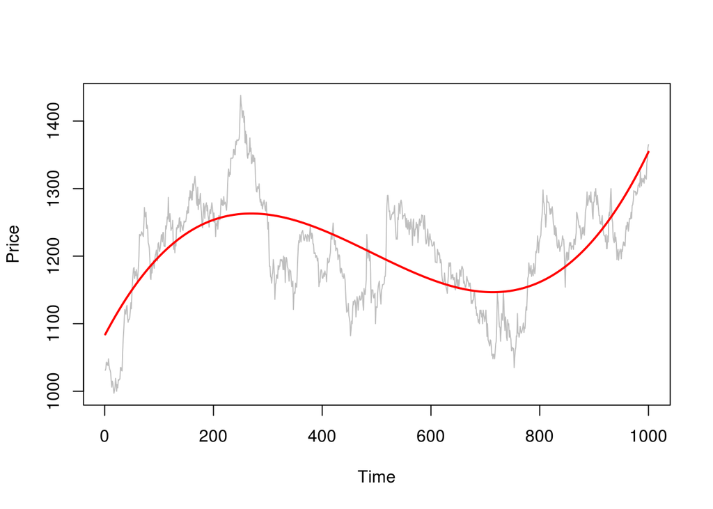

```r
plot.ts(X, type='l', col='gray', xlab = 'Time', ylab = 'Price' )
lines(n, predict(m3), lwd = 2, col = 'red')
```

> This time curve of model fits much better to the actual data then in previous cases. Let’s compute R², adjusted R².

```r
r.squared <- summary$r.squared
adj.r.squared <- summary$adj.r.squared
cat("R² =", r.squared)
```

```
## R² = 0.4260874
```

```r
cat("Adjusted R² =", adj.r.squared)
```

```
## Adjusted R² = 0.4243587
```

#### P-values of parameters :

```r
p.a <- summary$coefficients[1, 4]
cat("p.a =", p.a)
```

```
## p.a = 0
```

```r
p.b1 <- summary$coefficients[2, 4]
cat("p.b1 =", p.b1)
```

```
## p.b1 = 3.670723e-99
```

```r
p.b2 <- summary$coefficients[3, 4]
cat("p.b2 =", p.b2)
```

```
## p.b2 = 2.784842e-115
```

```r
p.b3 <- summary$coefficients[4, 4]
cat("p.b3 =", p.b3)
```

```
## p.b3 = 4.41209e-121
```

> P-values of parameters are almost zero and respect 5% confidence level. **Conclusion** : let’s stop on this model and analyze it.

> Let’s take a look on error between actual data and values predected by model :

```r
Y <- X - predict(m3)
mean_error <- mean(Y)
cat("Mean of Y =", mean_error)
```

```
## Mean of Y = 3.504726e-12
```

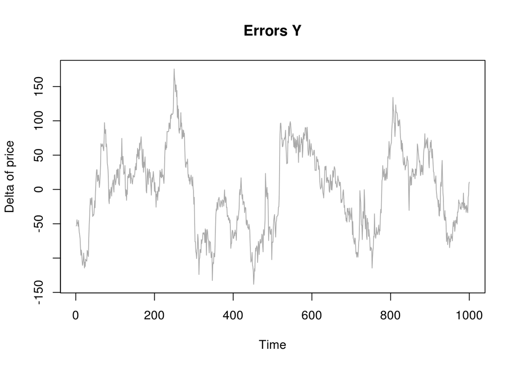

```r
plot.ts(Y, main = "Errors Y", col='dark gray', xlab = 'Time', ylab = 'Delta of price' )
```

> Though mean of `Y` almost equals to zero, curve of `Y` has a similar shape of initial data and does not really look like white noise. Nevertheless, let’s compute and plot autocovariance of `Y` :

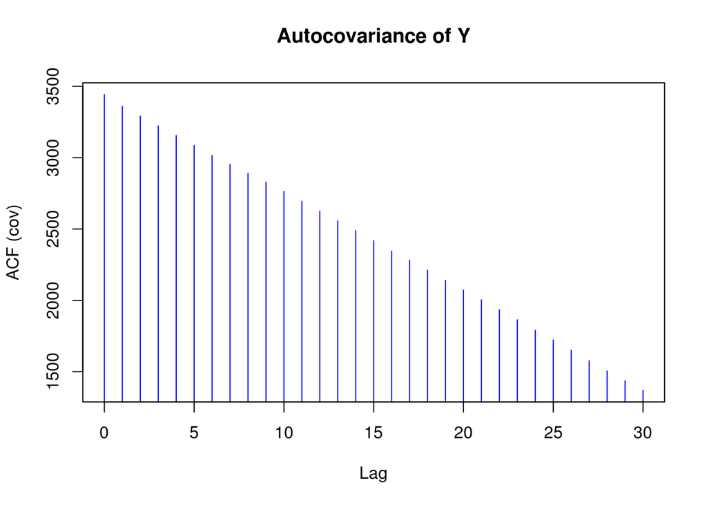

```r
autocov.Y <- acf(Y, type = "covariance", main="Autocovariance of Y", col = "blue")
```

> Plot of autocovariance of `Y` is supposed but does not look like Dirac signal at all, so we can conclude that given model is not the best solution for given data.

> Non-linear models are not good neither. It means that time `n` itself does not really explain the behavior of asset price `X` . There are other factors that may explain evolution of price but they are not of our interest now.

### PART 2 : autoregressive model $y_0 = (a_1*y_1 + a_2*y_2 + ... + a_p*y_p) + whiteNoise_0$

> Goal is to create a filter which transforms white noise to signal `Y` (errors between real and predicted values of price `X`) `ar()` function fits an autoregressive model to the data, by default selecting the complexity by Akaike Information Criterion. We apply Yule-Walker to find coefficients of the model

```r
temp <- ar.yw(Y)  # method = "yule-walker"
parameters <- temp$ar
print (parameters)
```

```
## [1] 0.91628673 0.06145462
```

> So we have 2 parameters and AR(p=2). Model has a following look : $y_0 = 0.91628673*y_1 + 0.06145462*y_2 + + whiteNoise_0$

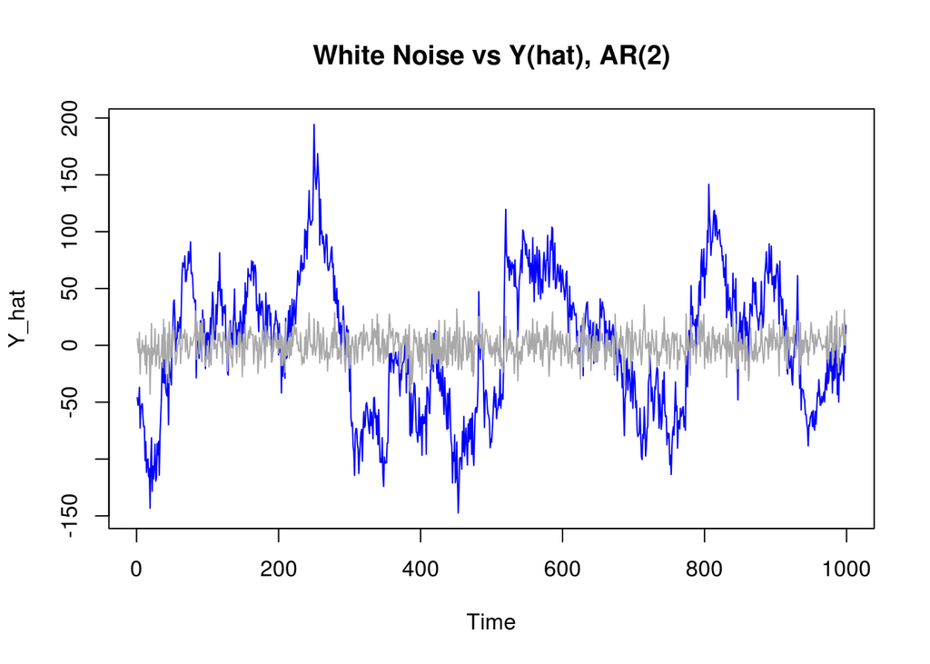

```r
AR2 <- function(y1, y2, whiteNoise){
    y0 <- parameters[1]*y1 + parameters[2]*y2 + whiteNoise
    y0
}
whiteNoise <- rnorm((N-1), sd = sqrt(temp$var.pred))
y_1 <- Y[1:(N-1)]
y_2 <- Y[2:N]
Y_hat <- AR2(y_1, y_2, whiteNoise)

plot.ts(Y_hat, col='blue', main="White Noise vs Y(hat), AR(2)")
lines(whiteNoise, col='dark gray')
```

### PART 3 : Analysis of resuduals

> We’ve got a new signal `Y_hat`. Now we can compare it with `Y` and analyze a difference between them.

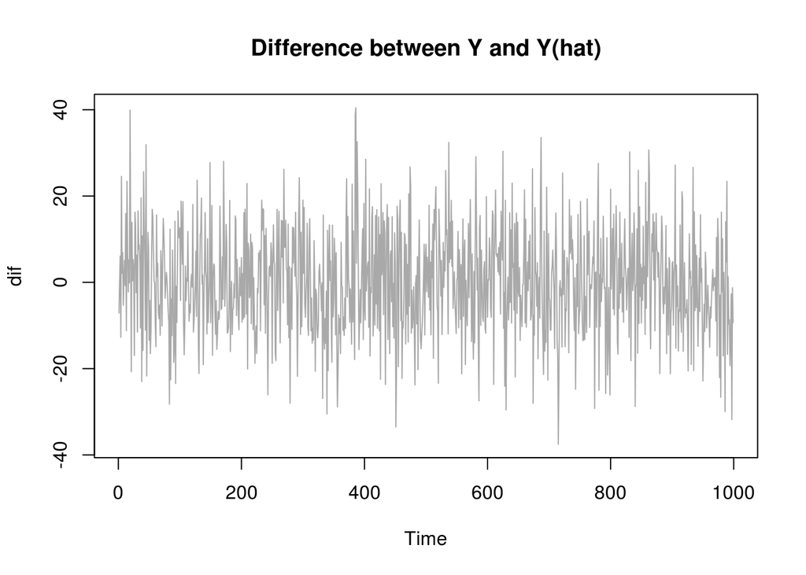

```r
dif <- Y[1:(N-1)] - Y_hat
plot.ts(dif, col='dark gray', main="Difference between Y and Y(hat)")
```

```r
cat("Mean of differences =", mean(dif))
```

```
## Mean of differences = 0.1335318
```

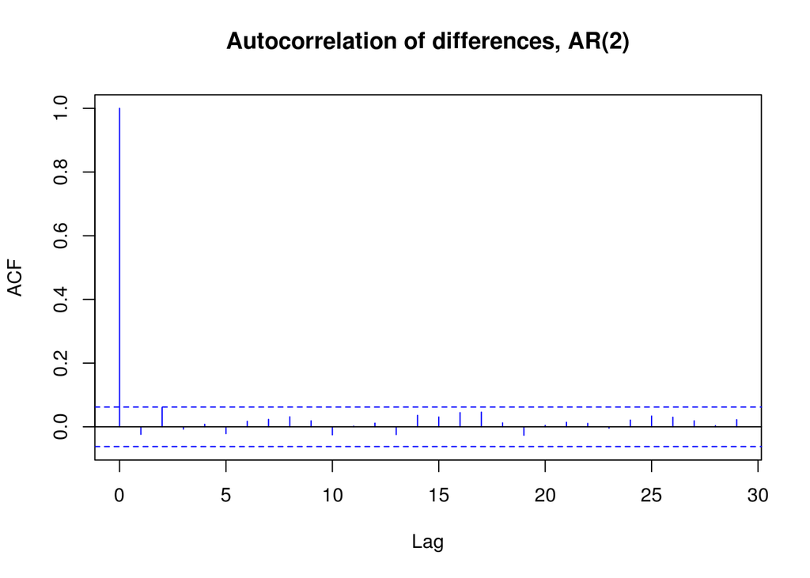

```r
# Autocorrelation of differences
autocov.dif <- acf(dif, type = "correlation",main="Autocorrelation of differences, AR(2)", col = "blue")
```

> Plot of autocorrelation of differences shows a perfect situation, we can recognize Dirac signal. At point 0 autocorrelation of `dif` between y0 and y0 equals to 1, which is logic. With lags bigger then 0 autocorrelation of `dif` is around zero. So differencies between `Y` and `Y_hat` are independend.

# Summary

> **In part 1** of this work I was trying 3 different models to fit the given data. Least squares method was applied using built-in R function `lm()`. Finally polynomial one of order 3 was chosen as the model with the best characteristics. However there was a prooblem - errors `Y` between real and predicted values of `X` were not random. I made such conclusion looking at the plot of `Y` and plot of autocovariance of `Y`. Last one was supposed to show graph similar to Dirac, but it was not a case. Nevertheless I stoped to analyze the last model.

> **In part 3** I simply compared `Y` and `Y_hat` and figured out that differences between them are completly random and that my AR(2) model is good.